# Step4. STEAM analysis

Please note that some steps have been pre-run in a separate vignette to generate the permutation matrices needed and to only keep genes in the gene lists that are present in the Seurat object after QC filtering.

# 1 Load libraries

Load the necessary libraries.

```r
library(Seurat)
library(SeuratObject)
library(dplyr)
library(MASS)
library(viridis)
library(stringr)
library(ggplot2)
library(readr)
library(steam)
```

# 2 Load data

Load Seurat object.

```r
se <- readRDS("data/mouse_CTX_HPF/se_250_cells_filtered_Metacell_normalized.rds")
se
```

```
## An object of class Seurat
## 30706 features across 943 samples within 2 assays
## Active assay: SCT (15353 features, 3000 variable features)
##  3 layers present: counts, data, scale.data
##  1 other assay present: RNA
```

```r
head(se[[]])
```

```
##          orig.ident nCount_RNA nFeature_RNA subclass_label nCount_SCT
## Astro_3       Astro      57468         8441          Astro      79033
## Astro_5       Astro      29083         6584          Astro      76368
## Astro_8       Astro      34064         7061          Astro      76916
## Astro_7       Astro      32007         6822          Astro      76820
## Astro_10      Astro      23964         6057          Astro      75978
## Astro_11      Astro      26672         6247          Astro      77128
##          nFeature_SCT
## Astro_3          8805
## Astro_5          9448
## Astro_8          9315
## Astro_7          9356
## Astro_10        10491
## Astro_11        10186
```

Load ranked gene lists (here from Open Targets). Please note that it is essential for downstream analysis that the gene lists are ranked from this point forward to do empirical selection of top genetic genes.

```r
OpenTargets_ALZ_Genetic_ <- as.character(t(read.table(file = "data/OpenTargets/ranked_gene_sets/OT-MONDO_0004975-associated-targets-8_25_2025-v25_06_ALZ_genetic_mouse.csv")))
length(OpenTargets_ALZ_Genetic_)
```

```
## [1] 819
```

# 3 Prepare data for STEAM analysis

Filter out genes not present in the Seurat object.

```r
# Extract gene names from the Seurat object
gene_names <- rownames(se)

# Remove genes not present in the Seurat object from the gene lists
OpenTargets_ALZ_Genetic_ <- unique(OpenTargets_ALZ_Genetic_[OpenTargets_ALZ_Genetic_ %in% gene_names])
length(OpenTargets_ALZ_Genetic_)
```

```
## [1] 621
```

Generate sliding window gene sets from gene lists. Select your choice of trait abbreviation (disease_abbr) and a gene list descriptive term (ot_gene_set_label). We select a window size of 50 genes, moving by 10 genes for each window.

```r
window_rank_list_ALZ_Genetic <- generate_sliding_windows(OpenTargets_ALZ_Genetic_, window_size = 50, step_size = 10, disease_abbr = "ALZ", ot_gene_set_label = "Genetic")
```

Add gene sets to a list.

```r
all_gene_sets_OpenTargets <- list(OpenTargets_ALZ_Genetic_=OpenTargets_ALZ_Genetic_)
```

Merge all gene sets into one list.

```r
all_gene_sets <- all_gene_sets_OpenTargets
all_gene_sets <- append(all_gene_sets,window_rank_list_ALZ_Genetic)
```

Calculate the average gene expression per gene list and check the percentage of genes present in the Seurat object. It is important that all genes used are present in the Seurat object, otherwise the downstream statistic assumptions are invalid.

```r
score.mat <- matrix(data = NA, nrow = length(all_gene_sets), ncol = 1, dimnames = list(names(all_gene_sets), "% of genes present"))

for (i in 1:length(all_gene_sets)) {
  genes <- unlist(all_gene_sets[i])
  score.mat[i] <- mean(genes %in% rownames(se))
  se <- AddModuleScore(se,list(genes), ctrl = 100, name = list(names(all_gene_sets[i])))
}

score.mat*100
```

```
##                          % of genes present
## OpenTargets_ALZ_Genetic_                100
## ALZ_Genetic_Rank1_                      100
## ALZ_Genetic_Rank2_                      100
## ALZ_Genetic_Rank3_                      100
## ALZ_Genetic_Rank4_                      100
## ALZ_Genetic_Rank5_                      100
## ALZ_Genetic_Rank6_                      100
## ALZ_Genetic_Rank7_                      100
## ALZ_Genetic_Rank8_                      100
## ALZ_Genetic_Rank9_                      100
## ALZ_Genetic_Rank10_                     100
## ALZ_Genetic_Rank11_                     100
## ALZ_Genetic_Rank12_                     100
## ALZ_Genetic_Rank13_                     100
## ALZ_Genetic_Rank14_                     100
## ALZ_Genetic_Rank15_                     100
## ALZ_Genetic_Rank16_                     100
## ALZ_Genetic_Rank17_                     100
## ALZ_Genetic_Rank18_                     100
## ALZ_Genetic_Rank19_                     100
## ALZ_Genetic_Rank20_                     100
## ALZ_Genetic_Rank21_                     100
## ALZ_Genetic_Rank22_                     100
## ALZ_Genetic_Rank23_                     100
## ALZ_Genetic_Rank24_                     100
## ALZ_Genetic_Rank25_                     100
## ALZ_Genetic_Rank26_                     100
## ALZ_Genetic_Rank27_                     100
## ALZ_Genetic_Rank28_                     100
## ALZ_Genetic_Rank29_                     100
## ALZ_Genetic_Rank30_                     100
## ALZ_Genetic_Rank31_                     100
## ALZ_Genetic_Rank32_                     100
## ALZ_Genetic_Rank33_                     100
## ALZ_Genetic_Rank34_                     100
## ALZ_Genetic_Rank35_                     100
## ALZ_Genetic_Rank36_                     100
## ALZ_Genetic_Rank37_                     100
## ALZ_Genetic_Rank38_                     100
## ALZ_Genetic_Rank39_                     100
## ALZ_Genetic_Rank40_                     100
## ALZ_Genetic_Rank41_                     100
## ALZ_Genetic_Rank42_                     100
## ALZ_Genetic_Rank43_                     100
## ALZ_Genetic_Rank44_                     100
## ALZ_Genetic_Rank45_                     100
## ALZ_Genetic_Rank46_                     100
## ALZ_Genetic_Rank47_                     100
## ALZ_Genetic_Rank48_                     100
## ALZ_Genetic_Rank49_                     100
## ALZ_Genetic_Rank50_                     100
## ALZ_Genetic_Rank51_                     100
## ALZ_Genetic_Rank52_                     100
## ALZ_Genetic_Rank53_                     100
## ALZ_Genetic_Rank54_                     100
## ALZ_Genetic_Rank55_                     100
## ALZ_Genetic_Rank56_                     100
## ALZ_Genetic_Rank57_                     100
## ALZ_Genetic_Rank58_                     100
```

Load permutation matrices for your selected window size and genetic gene list (see separate vignette on how to generate these). OBS! Make sure that you create the Seurat object in the same way (package and filtering) when generating permutation matrices as when you run STEAM.

```r
perm_files <- c(
  "data/mouse_CTX_HPF/permutation_matrices/perm.mat.par_p10000_g50.rds"
)

perm_matrices <- load_permutation_matrices(perm_files)
perm.mat.window.data <- as.data.frame(perm_matrices[[1]])

perm.mat.window.data[1:5,1:5]
```

```
##                Astro     CA1-ProS   CA2-IG-FC          CA3        Car3
## Perm_nr1 -0.01655073  0.107323817  0.11838675  0.138390480  0.11241636
## Perm_nr2  0.08465651 -0.003006653 -0.07871845 -0.011044624 -0.07439984
## Perm_nr3 -0.04140509 -0.029972426 -0.02593291 -0.033794034  0.12305115
## Perm_nr4 -0.08140158  0.005318836  0.07804835 -0.003390025 -0.05383025
## Perm_nr5 -0.08034826 -0.061478821 -0.02195220 -0.034820748 -0.08156352
```

# 4 Empirical selection of top genetic genes

Derive an empirical threshold for top genes of a ranked gene list by comparing the ranked window gene set signal to a null gene set of equal size.

```r
 window_results.g <- window_rank_enrichment_analysis(
   se = se,
   perm.mat.window.data = perm.mat.window.data,
   window_rank_list = window_rank_list_ALZ_Genetic,
   ot_gene_set_label = "Genetic",
   disease_abbr = "ALZ",
   cluster_anno = "subclass_label",
   imputation = "dynamic"#,
   #log_file = "data/mouse_CTX_HPF/log_files/log_file_pval_mat_genetic_window_SC_ALZ.txt"
 )

head(window_results.g)
```

```
##                                       cluster window median_score   p_value
## ALZ_Genetic_cluster_Astro_Rank1 cluster_Astro      1    0.1068265 6.480e-02
## ALZ_Genetic_cluster_Astro_Rank2 cluster_Astro      2    0.1248444 4.030e-02
## ALZ_Genetic_cluster_Astro_Rank3 cluster_Astro      3    0.1746883 1.150e-02
## ALZ_Genetic_cluster_Astro_Rank4 cluster_Astro      4    0.1844129 8.400e-03
## ALZ_Genetic_cluster_Astro_Rank5 cluster_Astro      5    0.3648366 9.999e-05
## ALZ_Genetic_cluster_Astro_Rank6 cluster_Astro      6    0.1883689 7.600e-03
##                                        q05       q95 is_significant was_imputed
## ALZ_Genetic_cluster_Astro_Rank1 -0.1010817 0.1170637          FALSE       FALSE
## ALZ_Genetic_cluster_Astro_Rank2 -0.1010817 0.1170637           TRUE       FALSE
## ALZ_Genetic_cluster_Astro_Rank3 -0.1010817 0.1170637           TRUE       FALSE
## ALZ_Genetic_cluster_Astro_Rank4 -0.1010817 0.1170637           TRUE       FALSE
## ALZ_Genetic_cluster_Astro_Rank5 -0.1010817 0.1170637           TRUE        TRUE
## ALZ_Genetic_cluster_Astro_Rank6 -0.1010817 0.1170637           TRUE       FALSE
##                                 imputation_type
## ALZ_Genetic_cluster_Astro_Rank1            none
## ALZ_Genetic_cluster_Astro_Rank2            none
## ALZ_Genetic_cluster_Astro_Rank3            none
## ALZ_Genetic_cluster_Astro_Rank4            none
## ALZ_Genetic_cluster_Astro_Rank5         dynamic
## ALZ_Genetic_cluster_Astro_Rank6            none
```

Plot median scores for each window in each cluster. Use these to identify sets of top genes. The lines represent the null distribution where, blue line = median, bright red = 95-quantile, dark red = max value. Here we see that for several clusters the top windows have signal above the max value, and we know the window size is 50 and moves by 10. Thus, we select the top 80 genes in this list to be our top set of genes.

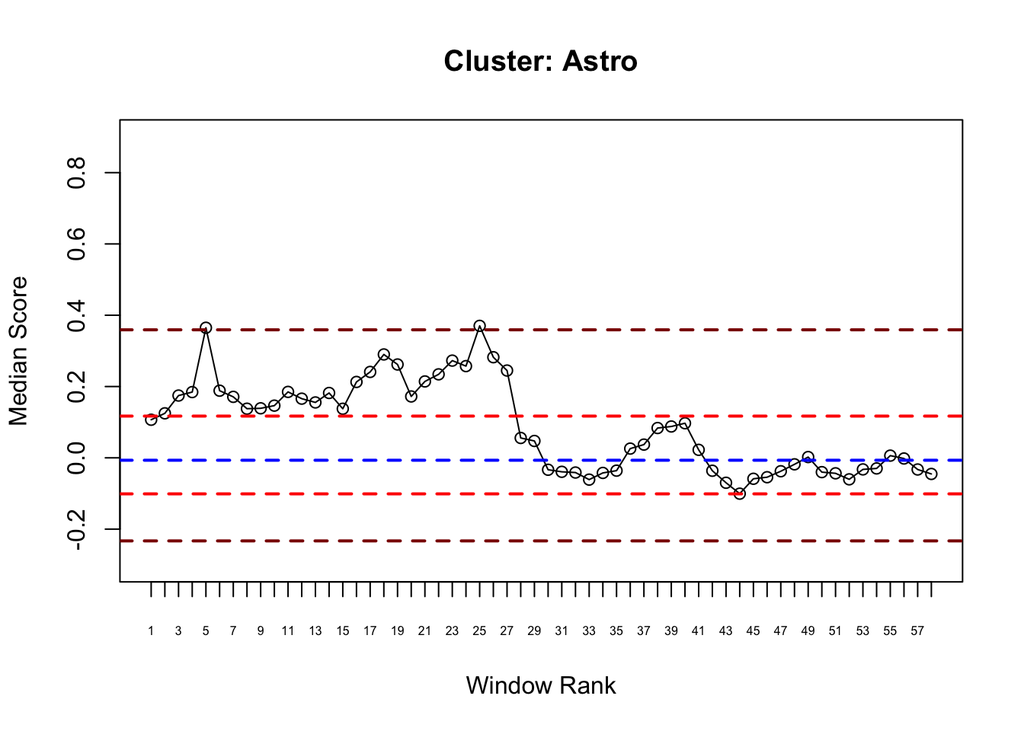

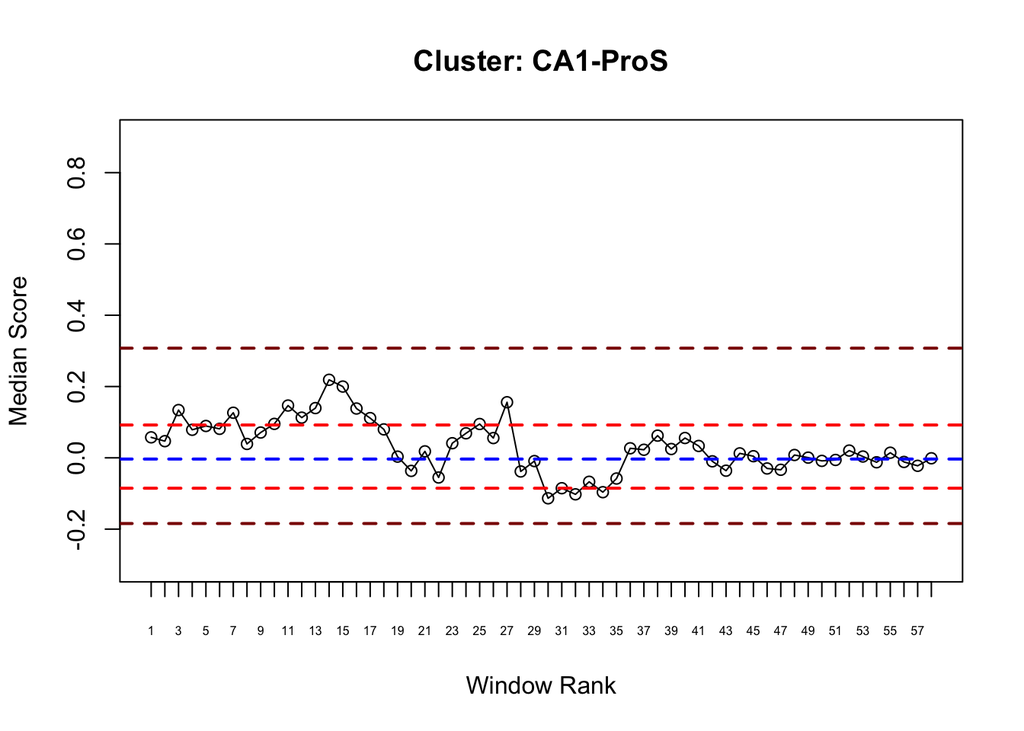

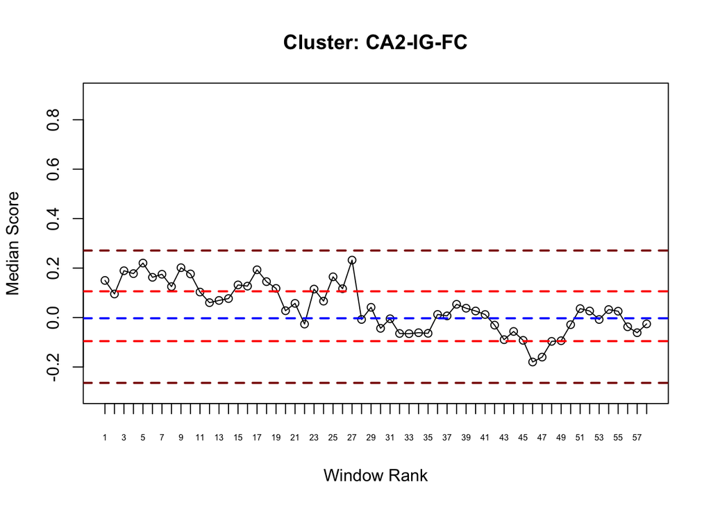

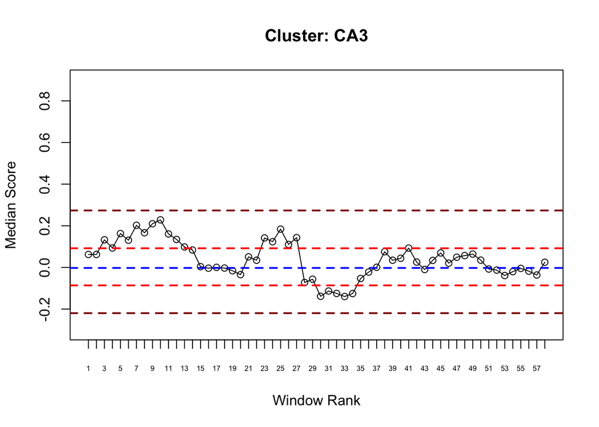

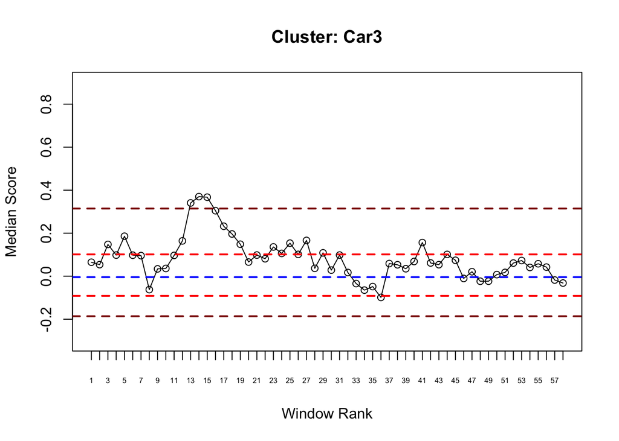

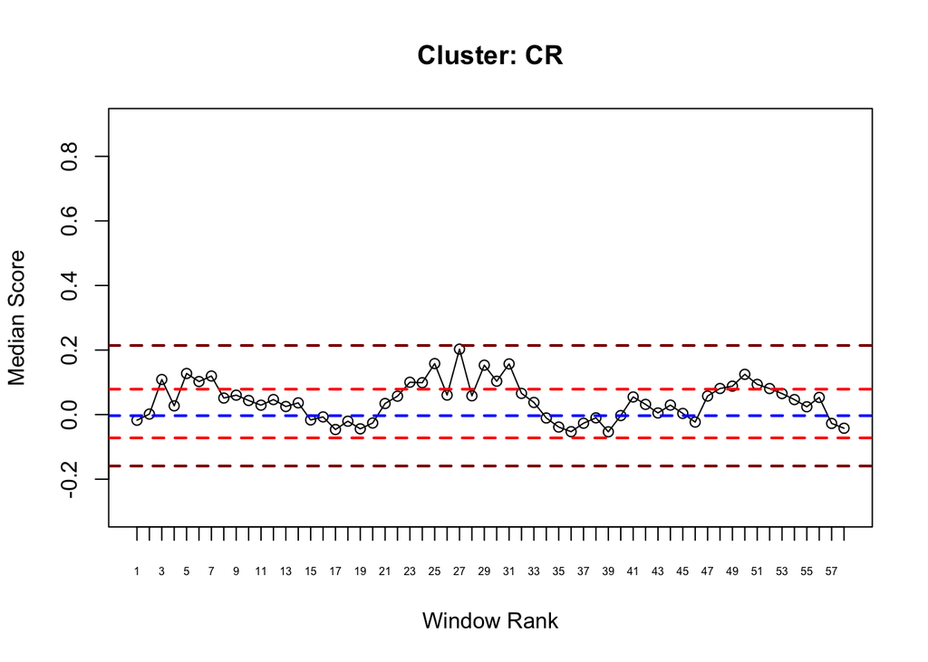

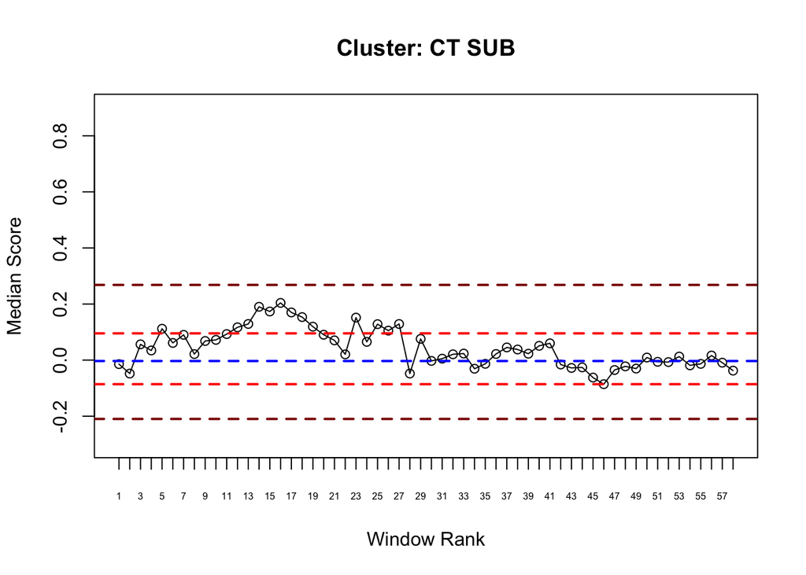

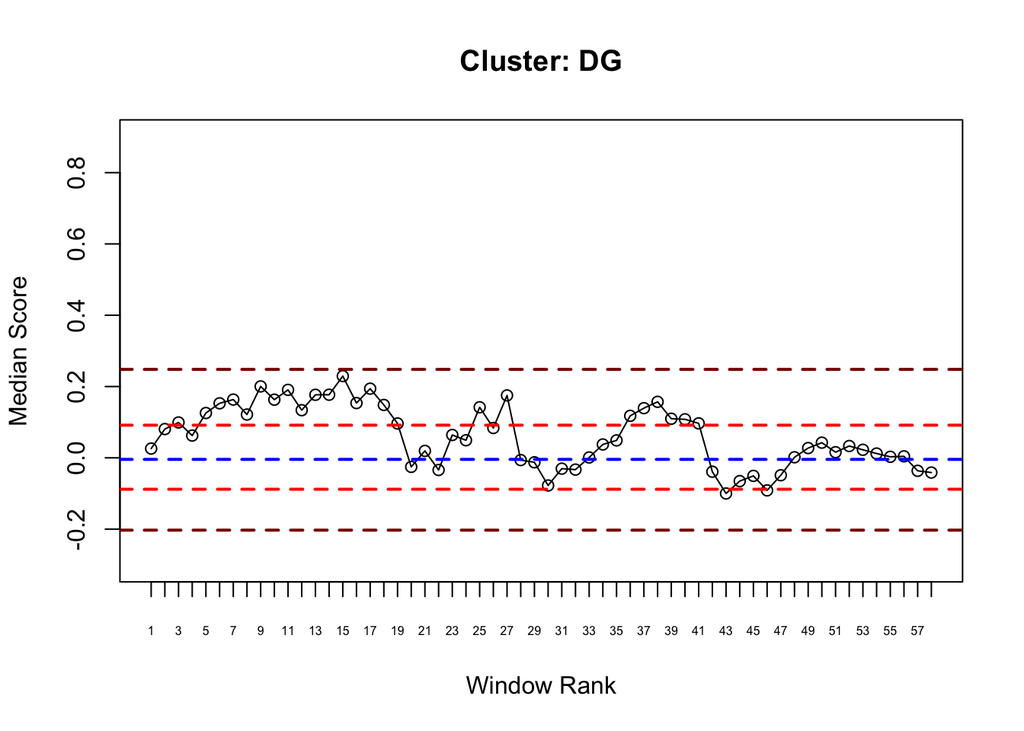

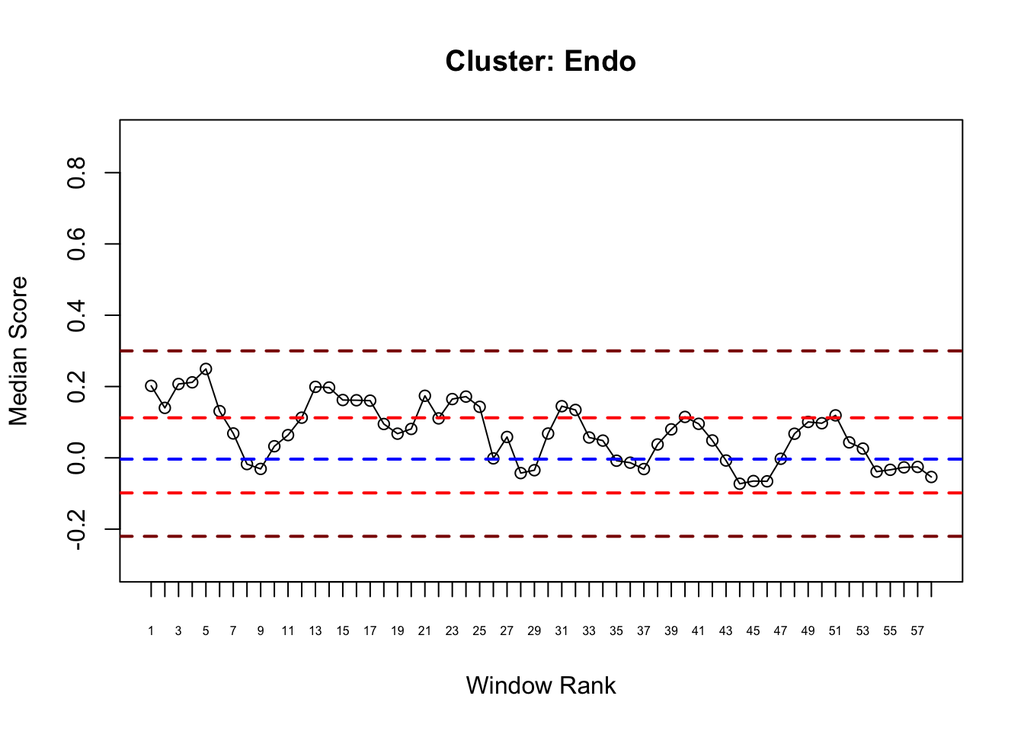

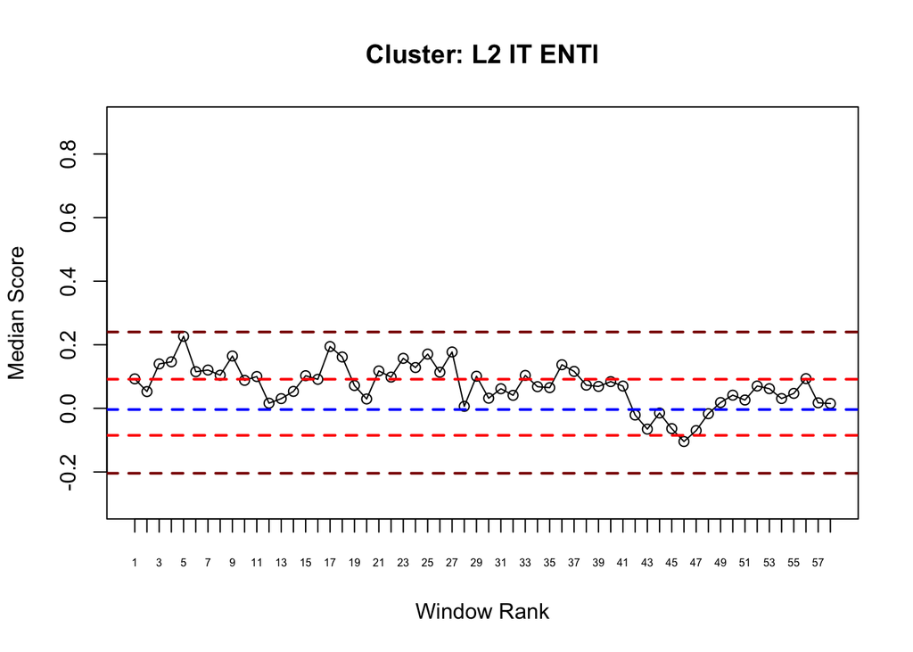

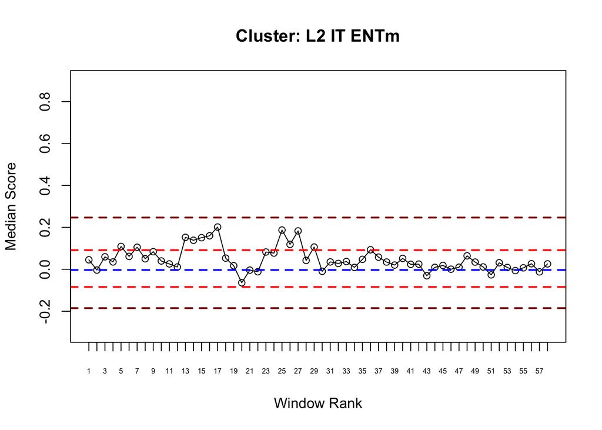

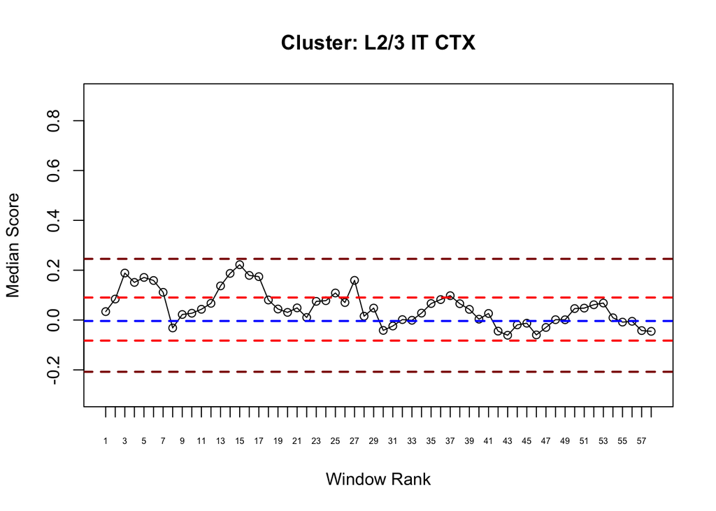

[29 more figures not shown]

```r
 rank_plot_for_clusters(
   window_results = window_results.g,
   perm.mat.window = perm.mat.window.data,
   ylim = c(-0.3, 0.9)
 )
```

# 5 Plot sliding window enrichment

Do multiple correction of p-values based on number of windows.

```r
window_results.g$p_value.adj <- p.adjust(window_results.g$p_value,method = "BH")
```

Add stars for plotting based on p_value.adj.

```r
window_results.g <- window_results.g%>%
  mutate(significance.level = ifelse(p_value.adj < 0.001, "***",
                     ifelse(p_value.adj < 0.01, "**",
                     ifelse(p_value.adj < 0.05, "*",
                     ""))))


window_results.g <- window_results.g%>%
  mutate(significant = ifelse(p_value.adj < 0.05, "TRUE",
                     "FALSE"))


head(window_results.g)
```

```
##                                       cluster window median_score   p_value
## ALZ_Genetic_cluster_Astro_Rank1 cluster_Astro      1    0.1068265 6.480e-02
## ALZ_Genetic_cluster_Astro_Rank2 cluster_Astro      2    0.1248444 4.030e-02
## ALZ_Genetic_cluster_Astro_Rank3 cluster_Astro      3    0.1746883 1.150e-02
## ALZ_Genetic_cluster_Astro_Rank4 cluster_Astro      4    0.1844129 8.400e-03
## ALZ_Genetic_cluster_Astro_Rank5 cluster_Astro      5    0.3648366 9.999e-05
## ALZ_Genetic_cluster_Astro_Rank6 cluster_Astro      6    0.1883689 7.600e-03
##                                        q05       q95 is_significant was_imputed
## ALZ_Genetic_cluster_Astro_Rank1 -0.1010817 0.1170637          FALSE       FALSE
## ALZ_Genetic_cluster_Astro_Rank2 -0.1010817 0.1170637           TRUE       FALSE
## ALZ_Genetic_cluster_Astro_Rank3 -0.1010817 0.1170637           TRUE       FALSE
## ALZ_Genetic_cluster_Astro_Rank4 -0.1010817 0.1170637           TRUE       FALSE
## ALZ_Genetic_cluster_Astro_Rank5 -0.1010817 0.1170637           TRUE        TRUE
## ALZ_Genetic_cluster_Astro_Rank6 -0.1010817 0.1170637           TRUE       FALSE
##                                 imputation_type p_value.adj significance.level
## ALZ_Genetic_cluster_Astro_Rank1            none 0.183883532
## ALZ_Genetic_cluster_Astro_Rank2            none 0.133101944
## ALZ_Genetic_cluster_Astro_Rank3            none 0.059450000
## ALZ_Genetic_cluster_Astro_Rank4            none 0.048720000                  *
## ALZ_Genetic_cluster_Astro_Rank5         dynamic 0.003963333                 **
## ALZ_Genetic_cluster_Astro_Rank6            none 0.046459640                  *
##                                 significant
## ALZ_Genetic_cluster_Astro_Rank1       FALSE
## ALZ_Genetic_cluster_Astro_Rank2       FALSE
## ALZ_Genetic_cluster_Astro_Rank3       FALSE
## ALZ_Genetic_cluster_Astro_Rank4        TRUE
## ALZ_Genetic_cluster_Astro_Rank5        TRUE
## ALZ_Genetic_cluster_Astro_Rank6        TRUE
```

Update cluster names in the cluster column.

```r
window_results.g$cluster <- gsub("^cluster_", "", window_results.g$cluster)
```

Plot WindowRankEnrichmentAnalysis results.

```r
# Set the order of window based on the original order of rbind
window_results.g$window <- factor(window_results.g$window,
                                     rev(unique(window_results.g$window)))


# Create the plot
p_all <- window_results.g %>%
  ggplot(aes(x = cluster, y = window)) +
  geom_tile(aes(fill = -log10(p_value.adj)), colour = "grey20") +  # Fill with adjusted p-value
  geom_text(data = window_results.g %>% filter(significant == TRUE),
            aes(label = significance.level),
            vjust = 0.75,
            size = 10,
            fontface = "bold") +
  theme(
    legend.key.width = unit(1.5, "cm"),
    legend.key.height = unit(1.5, "cm"),
    axis.text.x = element_text(angle = 90, vjust = 0.5, hjust = 1, size = 40),
    axis.text.y = element_text(size = 15),axis.title.x = element_text(size = 40, face = "bold"),axis.title.y = element_text(size = 40, face = "bold"),plot.title = element_text(size = 50, face = "bold"),legend.title = element_text(size = 40),legend.text = element_text(size = 40)
  ) +
  scale_x_discrete(labels = function(x) str_wrap(x, width = 22)) +
  coord_fixed(ratio = 0.25) +  # May need to adjust or remove if you want free y scaling
  labs(title = "All genetically associated ALZ genes",x = "Cluster", y = "Window rank", fill = "-log10(adj p-value) \n Benjamini & Hochberg") +
  scale_fill_viridis_c(begin = 0.2, option = "viridis") +
  scale_color_manual(values = c("*" = "white", "**" = "white", "***" = "white"),
                     labels = c("***" = "***  p < 0.001", "**" = "**  p < 0.01", "*" = "*  p < 0.05"),
                     guide = guide_legend(override.aes = list(shape = c(21, 21, 23),
                                                              fill = c("white", "white", "white"),
                                                              size = 4)))

p_all
```

[figure not shown]

PDF

```r
pdf(file = "data/mouse_CTX_HPF/STEAM_plots/WindowRankEnrichmentPlot_ALZ_adult.pdf", height = 50, width = 50)

p_all

dev.off()
```

# 6 Fisher’s exact test

Load DEGs data.

```r
DEG_genes <- read_csv2("data/mouse_CTX_HPF/DEG_output/DE_genes.csv")
DEG_genes <- as.data.frame(DEG_genes)
DEG_genes$p_val_adj <- as.numeric(DEG_genes$p_val_adj)
DEG_genes <- subset(DEG_genes, subset = p_val_adj <= 0.05) # using only significant DEG
```

Subset to select the top ranked genes.

```r
OpenTargets_ALZ_Genetic_top <- OpenTargets_ALZ_Genetic_[1:80]
length(OpenTargets_ALZ_Genetic_top)
```

```
## [1] 80
```

Run Fisher’s exact test.

```r
fisher_results <- run_fisher_test_degs(se, DEG_genes = DEG_genes, OT_genes = OpenTargets_ALZ_Genetic_top)
fisher_results
```

```
##            cluster      p_value odds_ratio  adj_p_value
## 1            Astro 2.973585e-01  1.3571485 1.000000e+00
## 2         CA1-ProS 1.538933e-01  1.8222189 1.000000e+00
## 3        CA2-IG-FC 5.299398e-02  2.0588318 1.000000e+00
## 4              CA3 3.518382e-01  1.3551153 1.000000e+00
## 5             Car3 6.345330e-01  0.9223549 1.000000e+00
## 6               CR 2.868917e-01  1.3398907 1.000000e+00
## 7           CT SUB 1.000000e+00  0.0000000 1.000000e+00
## 8               DG 4.090005e-01  1.2459609 1.000000e+00
## 9             Endo 9.317382e-04  2.8203205 3.820127e-02
## 10      L2 IT ENTl 7.335432e-02  2.0082025 1.000000e+00
## 11      L2 IT ENTm 3.375331e-01  1.3853171 1.000000e+00
## 12     L2/3 IT CTX 3.445870e-02  2.4073645 1.000000e+00
## 13    L2/3 IT ENTl 8.247565e-01  0.6303422 1.000000e+00
## 14     L2/3 IT PPP 6.450707e-01  0.9737165 1.000000e+00
```

[output cut: 27 more lines]

Plot results.

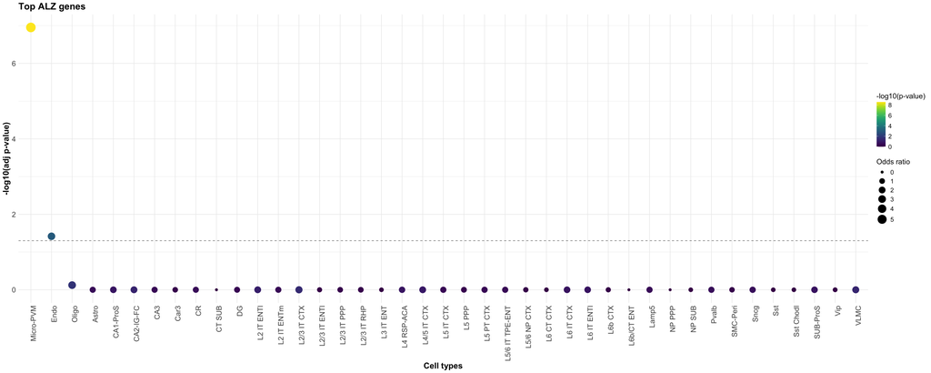

```r
# Ensure clusters are ordered by significance
fisher_results$cluster <- factor(fisher_results$cluster,
                                 levels = fisher_results$cluster[order(fisher_results$adj_p_value)])

# Create the updated plot with viridis scale
p1 <- ggplot(fisher_results, aes(x = cluster, color = -log10(p_value), y = -log10(adj_p_value), size = odds_ratio)) +
  geom_point() +
  geom_hline(yintercept = -log10(0.05), linetype = "dashed", color = "gray50") +
  scale_color_viridis(option = "D", direction = 1, name = "-log10(p-value)") +  # Use Viridis color scale
  scale_size_continuous(range = c(2, 8), name = "Odds ratio") +
  theme_minimal() +
  theme(axis.text.x = element_text(angle = 90, hjust = 1,size = 14),axis.text.y = element_text(size = 14),axis.title.x = element_text(size = 16, face = "bold"),axis.title.y = element_text(size = 16, face = "bold"),plot.title = element_text(size = 18, face = "bold"),legend.title = element_text(size = 14),legend.text = element_text(size = 12)) +
  labs(title = "Top ALZ genes",
       x = "Cell types",
       y = "-log10(adj p-value)") +
  guides(color = guide_colorbar(order = 1), size = guide_legend(order = 2))

p1
```

PDF

```r
pdf(file = "data/mouse_CTX_HPF/STEAM_plots/fishers_exact_test_DEGup_topSTEAM_ALZ_adult.pdf", height = 6, width = 12)

p1

dev.off()
```

Run Fisher’s exact test.

```r
fisher_results <- run_fisher_test_degs(se, DEG_genes = DEG_genes, OT_genes = OpenTargets_ALZ_Genetic_)
fisher_results
```

```
##            cluster      p_value odds_ratio adj_p_value
## 1            Astro 0.2662691192  1.1252380 1.000000000
## 2         CA1-ProS 0.5319466903  0.9998283 1.000000000
## 3        CA2-IG-FC 0.0031739147  1.5793607 0.130130502
## 4              CA3 0.1784696354  1.2244431 1.000000000
## 5             Car3 0.0044797564  1.6262204 0.183670012
## 6               CR 0.3666437398  1.0666031 1.000000000
## 7           CT SUB 0.0561584396  1.6589492 1.000000000
## 8               DG 0.0126346187  1.5293445 0.518019367
## 9             Endo 0.0239081552  1.3380498 0.980234365
## 10      L2 IT ENTl 0.0015737653  1.6709448 0.064524377
## 11      L2 IT ENTm 0.6813347707  0.9163315 1.000000000
## 12     L2/3 IT CTX 0.4412883651  1.0479321 1.000000000
## 13    L2/3 IT ENTl 0.5495837387  0.9897843 1.000000000
## 14     L2/3 IT PPP 0.0063903723  2.1259219 0.262005263
```

[output cut: 27 more lines]

Plot results.

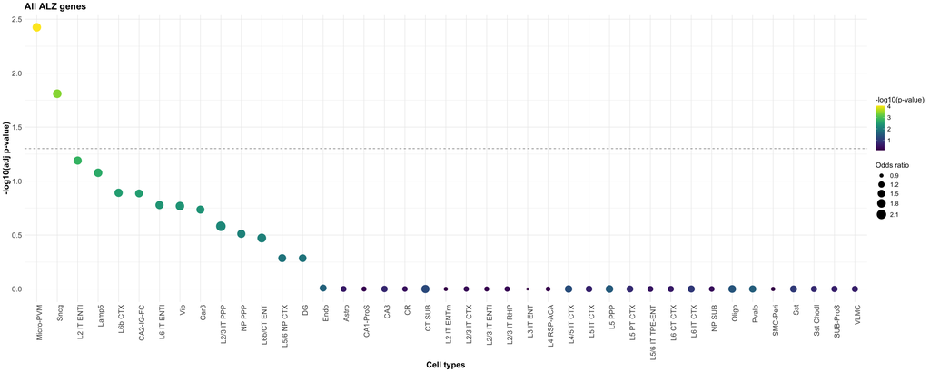

```r
# Ensure clusters are ordered by significance
fisher_results$cluster <- factor(fisher_results$cluster,
                                 levels = fisher_results$cluster[order(fisher_results$adj_p_value)])

# Create the updated plot with viridis scale
p2 <- ggplot(fisher_results, aes(x = cluster, color = -log10(p_value), y = -log10(adj_p_value), size = odds_ratio)) +
  geom_point() +
  geom_hline(yintercept = -log10(0.05), linetype = "dashed", color = "gray50") +
  scale_color_viridis(option = "D", direction = 1, name = "-log10(p-value)") +  # Use Viridis color scale
  scale_size_continuous(range = c(2, 8), name = "Odds ratio") +
  theme_minimal() +
  theme(axis.text.x = element_text(angle = 90, hjust = 1,size = 14),axis.text.y = element_text(size = 14),axis.title.x = element_text(size = 16, face = "bold"),axis.title.y = element_text(size = 16, face = "bold"),plot.title = element_text(size = 18, face = "bold"),legend.title = element_text(size = 14),legend.text = element_text(size = 12)) +
  labs(title = "All ALZ genes",
       x = "Cell types",
       y = "-log10(adj p-value)") +
  guides(color = guide_colorbar(order = 1), size = guide_legend(order = 2))

p2
```

PDF

```r
pdf(file = "data/mouse_CTX_HPF/STEAM_plots/fishers_exact_test_DEGup_all_ALZ_adult.pdf", height = 6, width = 12)

p2

dev.off()
```